# Bio 204: Problem Set 05

# Due Date: 07 November 2016

# Problem 1

The file [possums.txt](https://github.com/Bio204-class/bio204-datasets/raw/master/possum.txt) is a tab-delimited file that contains morphological measurements on 104 brushtail possums (*Trichosurus vulpecula*). This data set contains information on variables such as sex, age, head length, skull width, tail length, and total body length, as well as information about the population and locality (site) at which each specimen was collected.

## Problem 1a (3 pts)

For the variable `skullW` (skull width) evaluate how well the normal approximation holds by creating a density histogram and corresponding density plot (given the sample estimates of the mean and standard deviation).

[output not shown]

Your plot should look something like this:

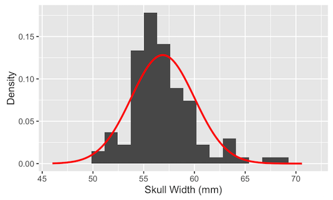

Possum Skull Width Histogram and Normal Distn w/same mean and sd

## Problem 1b (3 pts)

Create a a normal probability plot showing observed vs theoretical quantiles for the `skullW` variable.

[output not shown]

Your plot should look something like this:

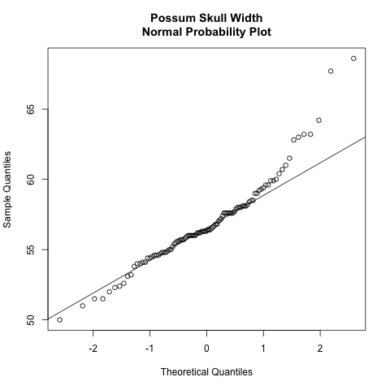

Possum Skull Width Normal Probability Plot

## Problem 1c (3 pts)?

Calculate the 95% and 99.7% confidence intervals for the mean of the skull width variable.

[output not shown]

# Problem 2

Consider a normal distribution, $\sim N(\mu = 20, \sigma = 2)$.

## Problem 2a (4 pts)

Both the mean and median are measures of location. In this problem you will complare the sampling distributions of these two statistics.

[output not shown]

Your plot should look something like this:

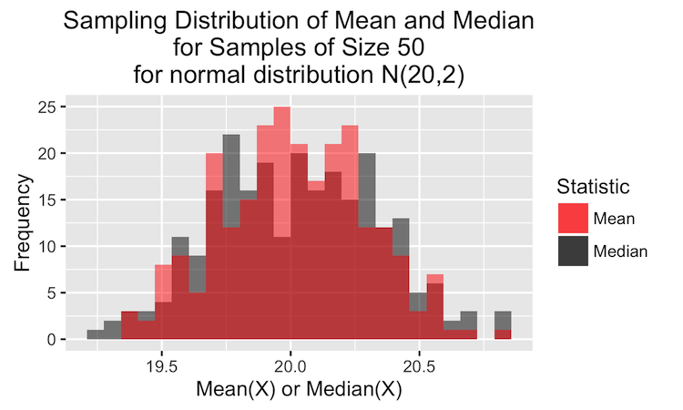

Sampling Distributions of Mean and Median

## Problem 2b (4 pts)

Write R code to simulate the sampling distribution of the **mean** and **median** for random samples of size: 10, 25, 50, 100, 200, 400, and 800. For each sample size, simulate the sampling distribution with 500 random samples and estimate the standard error of each statistic. Generate a pair of line plots comparing the standard error of both statistics of interest (mean and median) for the different sample sizes.

[output not shown]

Your plot should look something like this:

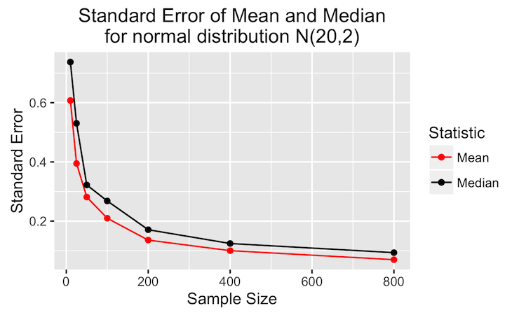

Standard Error of Mean and Median

## Problem 2c (3 pts)

From the simulations and figures you generated above, what conclusions do you draw about the sampling distributions of the mean and median?

[output not shown]